# CVLI no Ceará: crescimento 2022–2025, MQO e econometria espacial

# Resumo

**Objetivo.** Investigar a associação entre características municipais de 2022 e o crescimento do CVLI entre 2022 e 2025 nos municípios do Ceará, verificando se há dependência espacial nos resíduos e se os resultados são robustos à definição de vizinhança.

**Como o notebook está organizado**

| Seção | O que faz | Objetos principais |
| --- | --- | --- |
| 1. Configuração | Pacotes, opções e caminhos | `caminho_csv`, `pasta_malha` |
| 2. Dados | Importa a base, cria a resposta, define M1–M3 e a amostra comum | `df`, `base_modelo`, `formula1–3` |
| 3. MQO | Estima M1–M3 e faz diagnósticos clássicos | `modelo1–3`, `modelo3_lm` |
| 4. Estrutura espacial | Malha do IBGE, matriz rainha e matrizes KNN | `pesos_w`, `lista_w` |
| 5. Diagnósticos espaciais | Moran e testes RS para cada matriz | `diag_w` |
| 6. Máxima verossimilhança | SEM, SAR, SARAR e SDM (matriz rainha) | `mod_sem`, `mod_sar`, … |
| 7. GMM | SEM por GMM com cada matriz | `gmm_por_w`, `tab_robustez` |
| 8. Pontos para discussão | Decisões que precisam de validação | — |

**Convenções**

- **Resposta:** diferença de logaritmos com adição de 1 às contagens, `log(1 + CVLI_2025) - log(1 + CVLI_2022)`. Não é o crescimento percentual usual nem a variação da taxa por habitante.
- **Participações setoriais (`tx_*`):** mantidas na escala original da base.
- **Valores ausentes:** nunca são substituídos por zero.
- **Matrizes de pesos (W):** todas padronizadas por linha (`style = "W"`) e com `zero.policy = FALSE`, de modo que nenhum município pode ficar sem vizinho.
- **Amostra:** única e comum a todos os modelos (definida em 2.3).
- **Chamadas `pacote::funcao`:** usadas para evitar conflitos entre bibliotecas.
- **Execução:** rodar os blocos na ordem.

# 1 Configuração

```r
# Instale uma única vez, se necessário:
# install.packages(c("fixest", "readr", "car", "sf", "spdep", "lmtest",
#                    "sandwich", "spatialreg", "sphet", "knitr", "rmarkdown"))

pacotes = c("fixest", "readr", "car", "sf", "spdep", "lmtest", "sandwich",
            "spatialreg", "sphet", "knitr", "rmarkdown")
faltantes = pacotes[!vapply(pacotes, requireNamespace, logical(1), quietly = TRUE)]
if (length(faltantes) > 0) {
  stop("Instale antes os pacotes: ", paste(faltantes, collapse = ", "))
}

options(scipen = 999, width = 180)
knitr::opts_chunk$set(echo = TRUE, warning = TRUE, message = FALSE)

# Caminho da base. Para outra pessoa executar, basta ajustar esta linha.
caminho_csv = path.expand("~/violência/data/crime_violento_2022_2025.csv")

# Cache persistente da malha, ao lado do CSV.
pasta_malha = file.path(dirname(caminho_csv), "malha_ce_2022")
```

# 2 Dados

## 2.1 Importação e variável dependente

- Lê o CSV e padroniza os nomes das colunas (remove BOM e espaços).
- Exige `code_muni` único e sem ausentes, pois ele é a chave de ligação com a malha.
- Impede `log1p` de contagens negativas.

```r
df = as.data.frame(readr::read_csv(caminho_csv, show_col_types = FALSE))
names(df) = trimws(sub("^\ufeff", "", names(df)))

if (!"code_muni" %in% names(df)) stop("A base precisa da coluna code_muni.")
df$code_muni = as.character(df$code_muni)
stopifnot(!anyNA(df$code_muni), !anyDuplicated(df$code_muni))

stopifnot(all(df$cvli_2022 >= 0, na.rm = TRUE),
          all(df$cvli_2025 >= 0, na.rm = TRUE))

df$crescimento_cvli_log_2022_2025 =
  log1p(df$cvli_2025) - log1p(df$cvli_2022)
```

## 2.2 Especificações dos modelos

| Modelo | Conteúdo |
| --- | --- |
| **M1** | Controles de 2022 e crescimento populacional; sem setores e sem CVLI inicial |
| **M2** | M1 + CVLI inicial + seis participações setoriais (inclui `tx_adm_pub`) |
| **M3** | M2 sem `tx_adm_pub`. É a **especificação principal** usada nos modelos espaciais |

```r
formula1 = crescimento_cvli_log_2022_2025 ~
  log(urbanizacao_2022) +
  log(taxa_desocupacao_2022_pct) +
  log(rendimento_medio_mensal_2022_brl) +
  log(populacao_2022) +
  crescimento_populacional_2022_2025_pct +
  log(densidade_2022_hab_km2) +
  log(taxa_sem_instrucao_ou_fundamental_incompleto_2022_pct)

formula2 = update(
  formula1,
  . ~ . + log1p(cvli_2022) + tx_adm_pub + tx_agro + tx_comercio +
    tx_construcao_civil + tx_industria_transformacao + tx_servicos
)

formula3 = update(formula2, . ~ . - tx_adm_pub)
```

## 2.3 Amostra comum

- A amostra é definida pela especificação mais ampla (M2), **antes** de estimar.
- Linhas com valores ausentes ou não finitos são listadas e excluídas dos três modelos. Se houver exclusões, o motivo deve ser avaliado: não se trata de uma limpeza substantivamente justificada de forma automática.
- Zero em uma participação setorial é um valor válido.
- Variáveis em log precisam ser estritamente positivas (verificado abaixo).

```r
vars_log = c(
  "urbanizacao_2022", "taxa_desocupacao_2022_pct",
  "rendimento_medio_mensal_2022_brl", "populacao_2022",
  "densidade_2022_hab_km2",
  "taxa_sem_instrucao_ou_fundamental_incompleto_2022_pct"
)

nao_positivos = vapply(df[vars_log], function(x) sum(x <= 0, na.rm = TRUE), numeric(1))
if (any(nao_positivos > 0)) {
  print(nao_positivos[nao_positivos > 0])
  stop("Há zeros ou negativos em variáveis com log. Reveja a transformação.")
}

quadro_completo = model.frame(formula2, data = df, na.action = na.pass)
valida = Reduce(`&`, lapply(quadro_completo, is.finite))

if (any(!valida)) {
  print(df[!valida, intersect(c("code_muni", "municipio"), names(df)), drop = FALSE])
}

base_modelo = df[valida, , drop = FALSE]
base_modelo = base_modelo[order(base_modelo$code_muni), , drop = FALSE]
rownames(base_modelo) = base_modelo$code_muni
stopifnot(nrow(base_modelo) > ncol(quadro_completo))

print(data.frame(
  Total = nrow(df), Incluidos = nrow(base_modelo), Excluidos = sum(!valida)
))
```

```
  Total Incluidos Excluidos
1   184       184         0
```

# 3 MQO e diagnósticos clássicos

## 3.1 Estimação (`fixest`)

Os três modelos são estimados com `fixest::feols()` **sem efeitos fixos** (há uma observação por município), com erros-padrão homocedásticos (`vcov = "iid"`). O `fixest` não substitui os estimadores espaciais das seções seguintes.

```r
modelo1 = fixest::feols(formula1, data = base_modelo, vcov = "iid")
modelo2 = fixest::feols(formula2, data = base_modelo, vcov = "iid")
modelo3 = fixest::feols(formula3, data = base_modelo, vcov = "iid")

summary(modelo1)
```

```
OLS estimation, Dep. Var.: crescimento_cvli_log_2022_2025
Observations: 184
Standard-errors: IID
```

|  | Estimate | Std. Error | t value | Pr(>\|t\|) |  |
| --- | --- | --- | --- | --- | --- |
| (Intercept) | 0.829151 | 5.387121 | 0.153914 | 0.877854 |  |
| log(urbanizacao_2022) | -0.388106 | 0.275339 | -1.409557 | 0.160435 |  |
| log(taxa_desocupacao_2022_pct) | 0.202083 | 0.125233 | 1.613658 | 0.108393 |  |
| log(rendimento_medio_mensal_2022_brl) | -0.321518 | 0.475631 | -0.675982 | 0.499939 |  |
| log(populacao_2022) | 0.150440 | 0.084222 | 1.786238 | 0.075782 | . |
| crescimento_populacional_2022_2025_pct | 0.017107 | 0.029350 | 0.582858 | 0.560735 |  |
| log(densidade_2022_hab_km2) | 0.020325 | 0.084417 | 0.240768 | 0.810015 |  |
| log(taxa_sem_instrucao_ou_fundamental_incompleto_2022_pct) | -0.223506 | 0.694986 | -0.321598 | 0.748139 |  |

```
---
Signif. codes:  0 '***' 0.001 '**' 0.01 '*' 0.05 '.' 0.1 ' ' 1
RMSE: 0.70396   Adj. R2: 0.015842
```

```r
summary(modelo2)
```

```
OLS estimation, Dep. Var.: crescimento_cvli_log_2022_2025
Observations: 184
Standard-errors: IID
```

|  | Estimate | Std. Error | t value | Pr(>\|t\|) |  |
| --- | --- | --- | --- | --- | --- |
| (Intercept) | -0.369958 | 4.929439 | -0.075051 | 0.9402630754748165 |  |
| log(urbanizacao_2022) | -0.178704 | 0.249883 | -0.715151 | 0.4755024535373494 |  |
| log(taxa_desocupacao_2022_pct) | 0.110054 | 0.108627 | 1.013139 | 0.3124421819402856 |  |
| log(rendimento_medio_mensal_2022_brl) | -0.214996 | 0.416317 | -0.516424 | 0.6062331675007828 |  |
| log(populacao_2022) | 0.641684 | 0.096314 | 6.662426 | 0.0000000003636592 | *** |
| crescimento_populacional_2022_2025_pct | -0.008057 | 0.025906 | -0.311023 | 0.7561666744888768 |  |
| log(densidade_2022_hab_km2) | 0.035622 | 0.074470 | 0.478347 | 0.6330215531425067 |  |
| log(taxa_sem_instrucao_ou_fundamental_incompleto_2022_pct) | -0.690828 | 0.627645 | -1.100666 | 0.2726073835955793 |  |
| log1p(cvli_2022) | -0.542856 | 0.070759 | -7.671874 | 0.0000000000012827 | *** |
| tx_adm_pub | -1.115164 | 1.882830 | -0.592281 | 0.5544540254109098 |  |

[output cut: 5 more lines]

```
---
Signif. codes:  0 '***' 0.001 '**' 0.01 '*' 0.05 '.' 0.1 ' ' 1
RMSE: 0.586675   Adj. R2: 0.288149
```

```r
summary(modelo3)
```

```
OLS estimation, Dep. Var.: crescimento_cvli_log_2022_2025
Observations: 184
Standard-errors: IID
```

|  | Estimate | Std. Error | t value | Pr(>\|t\|) |  |
| --- | --- | --- | --- | --- | --- |
| (Intercept) | -1.158473 | 4.737186 | -0.244549 | 0.8071007134925310 |  |
| log(urbanizacao_2022) | -0.168211 | 0.248778 | -0.676148 | 0.4998653346910108 |  |
| log(taxa_desocupacao_2022_pct) | 0.110873 | 0.108411 | 1.022709 | 0.3078983478715613 |  |
| log(rendimento_medio_mensal_2022_brl) | -0.238162 | 0.413683 | -0.575712 | 0.5655713935610017 |  |
| log(populacao_2022) | 0.644486 | 0.096014 | 6.712436 | 0.0000000002738758 | *** |
| crescimento_populacional_2022_2025_pct | -0.007068 | 0.025803 | -0.273903 | 0.7844914279878182 |  |
| log(densidade_2022_hab_km2) | 0.029799 | 0.073677 | 0.404460 | 0.6863831678637702 |  |
| log(taxa_sem_instrucao_ou_fundamental_incompleto_2022_pct) | -0.731471 | 0.622690 | -1.174695 | 0.2417597141211433 |  |
| log1p(cvli_2022) | -0.543817 | 0.070605 | -7.702204 | 0.0000000000010536 | *** |
| tx_agro | 0.361613 | 0.823080 | 0.439341 | 0.6609723660512397 |  |

[output cut: 4 more lines]

```
---
Signif. codes:  0 '***' 0.001 '**' 0.01 '*' 0.05 '.' 0.1 ' ' 1
RMSE: 0.587283   Adj. R2: 0.290867
```

## 3.2 Cópias `lm` para os diagnósticos

`lm.morantest()` e `lm.RStests()` exigem objetos da classe `lm`. Criam-se cópias equivalentes de M2 e M3 na mesma amostra, **sem alterar a especificação**. O bloco confere se coeficientes e número de observações coincidem com o `fixest`.

```r
modelo2_lm = lm(formula2, data = base_modelo, na.action = na.fail)
modelo3_lm = lm(formula3, data = base_modelo, na.action = na.fail)

b_fixest = coef(modelo3)
b_lm = coef(modelo3_lm)[names(b_fixest)]
stopifnot(
  nobs(modelo3) == nobs(modelo3_lm),
  length(b_fixest) == length(coef(modelo3_lm)),
  !anyNA(b_lm),
  isTRUE(all.equal(unname(b_fixest), unname(b_lm), tolerance = 1e-6))
)
```

## 3.3 Multicolinearidade (VIF)

```r
car::vif(modelo2_lm)
```

```
                                     log(urbanizacao_2022)                             log(taxa_desocupacao_2022_pct)
                                                  1.794746                                                   1.081465
                     log(rendimento_medio_mensal_2022_brl)                                        log(populacao_2022)
                                                  2.752991                                                   3.547303
                    crescimento_populacional_2022_2025_pct                                log(densidade_2022_hab_km2)
                                                  1.831256                                                   2.762346
log(taxa_sem_instrucao_ou_fundamental_incompleto_2022_pct)                                           log1p(cvli_2022)
                                                  4.941290                                                   2.891308
                                                tx_adm_pub                                                    tx_agro
                                                118.214104                                                   6.813549
                                               tx_comercio                                        tx_construcao_civil
                                                 10.703510                                                   3.669245
                                tx_industria_transformacao                                                tx_servicos
                                                 37.379053                                                  30.708099
```

```r
car::vif(modelo3_lm)
```

```
                                     log(urbanizacao_2022)                             log(taxa_desocupacao_2022_pct)
                                                  1.785724                                                   1.081290
                     log(rendimento_medio_mensal_2022_brl)                                        log(populacao_2022)
                                                  2.728691                                                   3.538744
                    crescimento_populacional_2022_2025_pct                                log(densidade_2022_hab_km2)
                                                  1.823634                                                   2.714199
log(taxa_sem_instrucao_ou_fundamental_incompleto_2022_pct)                                           log1p(cvli_2022)
                                                  4.882225                                                   2.889786
                                                   tx_agro                                                tx_comercio
                                                  1.102798                                                   1.617458
                                       tx_construcao_civil                                 tx_industria_transformacao
                                                  1.114988                                                   1.676532
                                               tx_servicos
                                                  1.574588
```

## 3.4 Heterocedasticidade (Breusch–Pagan e HC3)

- O teste de Breusch–Pagan é usado na versão studentizada.
- O HC3 serve apenas como **sensibilidade da inferência do MQO** à heterocedasticidade. Ele **não** corrige dependência espacial e não é a covariância do SEM.

```r
bp = lmtest::bptest(modelo3_lm, studentize = TRUE)
bp
```

```
    studentized Breusch-Pagan test

data:  modelo3_lm
BP = 11.291, df = 13, p-value = 0.5864
```

```r
vcov_hc3 = sandwich::vcovHC(modelo3_lm, type = "HC3")
vcov_hc3 = vcov_hc3[names(coef(modelo3)), names(coef(modelo3)), drop = FALSE]
summary(modelo3, vcov = vcov_hc3)
```

```
OLS estimation, Dep. Var.: crescimento_cvli_log_2022_2025
Observations: 184
Standard-errors: Custom
```

|  | Estimate | Std. Error | t value | Pr(>\|t\|) |  |
| --- | --- | --- | --- | --- | --- |
| (Intercept) | -1.158473 | 4.769516 | -0.242891 | 0.8083825319150584 |  |
| log(urbanizacao_2022) | -0.168211 | 0.281722 | -0.597080 | 0.5512482930185987 |  |
| log(taxa_desocupacao_2022_pct) | 0.110873 | 0.100511 | 1.103088 | 0.2715481636725615 |  |
| log(rendimento_medio_mensal_2022_brl) | -0.238162 | 0.386783 | -0.615751 | 0.5388825635489076 |  |
| log(populacao_2022) | 0.644486 | 0.114200 | 5.643485 | 0.0000000684509096 | *** |
| crescimento_populacional_2022_2025_pct | -0.007068 | 0.020261 | -0.348821 | 0.7276552046747825 |  |
| log(densidade_2022_hab_km2) | 0.029799 | 0.072162 | 0.412948 | 0.6801648089670567 |  |
| log(taxa_sem_instrucao_ou_fundamental_incompleto_2022_pct) | -0.731471 | 0.603648 | -1.211751 | 0.2272891309992151 |  |
| log1p(cvli_2022) | -0.543817 | 0.071176 | -7.640418 | 0.0000000000015069 | *** |
| tx_agro | 0.361613 | 0.666261 | 0.542750 | 0.5880128272611771 |  |

[output cut: 4 more lines]

```
---
Signif. codes:  0 '***' 0.001 '**' 0.01 '*' 0.05 '.' 0.1 ' ' 1
RMSE: 0.587283   Adj. R2: 0.290867
```

## 3.5 Gráficos de diagnóstico

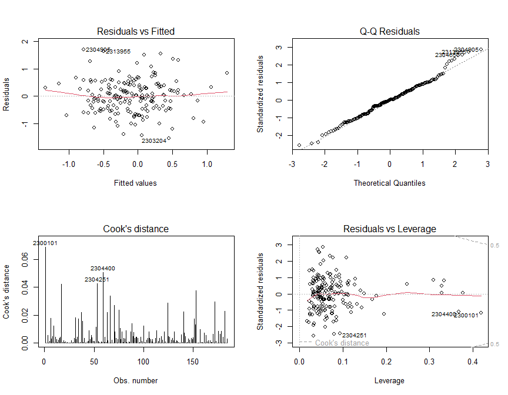

```r
op = par(mfrow = c(2, 2))
plot(modelo3_lm, which = c(1, 2, 4, 5))
par(op)
```

# 4 Estrutura espacial

## 4.1 Malha municipal (IBGE, 2022)

- Baixa a malha uma única vez e guarda em cache.
- Reprojeta para SIRGAS 2000 / UTM 24S (EPSG:31984, em metros).
- **Alinha** a malha à `base_modelo` pela chave `code_muni` e confere a ordem.

```r
dir.create(pasta_malha, recursive = TRUE, showWarnings = FALSE)
arquivo_zip = file.path(pasta_malha, "CE_Municipios_2022.zip")
url_malha = paste0(
  "https://geoftp.ibge.gov.br/organizacao_do_territorio/",
  "malhas_territoriais/malhas_municipais/",
  "municipio_2022/UFs/CE/CE_Municipios_2022.zip"
)

arquivo_shp = list.files(pasta_malha, pattern = "\\.shp$",
                         full.names = TRUE, recursive = TRUE)
if (length(arquivo_shp) == 0) {
  download.file(url_malha, destfile = arquivo_zip, mode = "wb")
  unzip(arquivo_zip, exdir = pasta_malha)
  arquivo_shp = list.files(pasta_malha, pattern = "\\.shp$",
                           full.names = TRUE, recursive = TRUE)
}
stopifnot(length(arquivo_shp) == 1)

malha_ce = sf::st_read(arquivo_shp, quiet = TRUE)
malha_ce = sf::st_transform(malha_ce, 31984)
malha_ce = sf::st_make_valid(malha_ce)
stopifnot(!anyDuplicated(as.character(malha_ce$CD_MUN)))

posicoes = match(base_modelo$code_muni, as.character(malha_ce$CD_MUN))
if (anyNA(posicoes)) stop("Há municípios da base sem correspondência na malha.")
malha_modelo = malha_ce[posicoes, ]

stopifnot(
  identical(as.character(malha_modelo$CD_MUN), base_modelo$code_muni),
  !any(sf::st_is_empty(malha_modelo))
)
```

## 4.2 Matriz de contiguidade rainha (1ª ordem) — matriz de referência

```r
vizinhos = spdep::poly2nb(
  malha_modelo, queen = TRUE, row.names = base_modelo$code_muni
)

summary(spdep::card(vizinhos))
```

```
   Min. 1st Qu.  Median    Mean 3rd Qu.    Max.
  1.000   4.000   5.000   5.435   7.000  13.000
```

```r
sem_vizinhos = which(spdep::card(vizinhos) == 0)
if (length(sem_vizinhos) > 0) {
  print(sf::st_drop_geometry(malha_modelo[sem_vizinhos, c("CD_MUN", "NM_MUN")]))
  stop("Existem municípios sem vizinhos. Reveja a geometria/amostra antes de continuar.")
}

spdep::n.comp.nb(vizinhos)$nc
```

```
[1] 1
```

```r
pesos_w = spdep::nb2listw(vizinhos, style = "W", zero.policy = FALSE)

stopifnot(
  identical(rownames(model.frame(modelo3_lm)), attr(vizinhos, "region.id")),
  nobs(modelo3) == length(vizinhos)
)
```

## 4.3 Matrizes de k vizinhos mais próximos (KNN) — análise de robustez

- Distância euclidiana entre centroides, em CRS projetado (`longlat = FALSE`).
- k = 4, 6, 8 e 10. Todos os municípios têm exatamente k vizinhos.
- A relação KNN é **assimétrica** por construção (`sim = FALSE`): A pode ser vizinho de B sem que B seja vizinho de A. Para forçar simetria, usar `sim = TRUE` (o número de vizinhos deixa de ser constante).
- `lista_w` reúne a matriz rainha e as KNN. O bloco confere o alinhamento com `base_modelo` e resume a estrutura de cada matriz.

```r
coords = sf::st_coordinates(sf::st_centroid(sf::st_geometry(malha_modelo)))
ks = c(4, 6, 8, 10)

cria_w_knn = function(k, coords, ids, sim = FALSE) {
  kn = spdep::knearneigh(coords, k = k, longlat = FALSE)
  nb = spdep::knn2nb(kn, row.names = ids, sym = sim)
  spdep::nb2listw(nb, style = "W", zero.policy = FALSE)
}

lista_w = c(
  list(Queen = pesos_w),
  setNames(
    lapply(ks, cria_w_knn, coords = coords, ids = base_modelo$code_muni),
    paste0("KNN", ks)
  )
)

stopifnot(vapply(lista_w, function(w)
  identical(attr(w$neighbours, "region.id"), base_modelo$code_muni), logical(1)))

resumo_w = do.call(rbind, lapply(names(lista_w), function(nm) {
  nb = lista_w[[nm]]$neighbours
  n_viz = spdep::card(nb)
  data.frame(W = nm, Min = min(n_viz), Media = round(mean(n_viz), 2),
             Max = max(n_viz), Componentes = spdep::n.comp.nb(nb)$nc,
             Simetrica = spdep::is.symmetric.nb(nb, verbose = FALSE, force = TRUE))
}))
print(resumo_w, row.names = FALSE)
```

```
     W Min Media Max Componentes Simetrica
 Queen   1  5.43  13           1      TRUE
  KNN4   4  4.00   4           1     FALSE
  KNN6   6  6.00   6           1     FALSE
  KNN8   8  8.00   8           1     FALSE
 KNN10  10 10.00  10           1     FALSE
```

# 5 Diagnósticos espaciais do MQO (M3)

Quatro perguntas, respondidas para **cada** matriz de `lista_w`:

- **Moran de Y:** a variável dependente é espacialmente autocorrelacionada?
- **Moran dos resíduos:** há autocorrelação espacial que o MQO não captura? (pergunta distinta da anterior)
- **RS-erro / RS-lag:** testes de multiplicadores de Lagrange para erro e defasagem.
- **RS ajustados (robustos):** cada um testa uma forma de dependência **considerando a outra**. Não são correção geral para heterocedasticidade.

**Leitura usual:** se os testes simples rejeitam, comparam-se as versões ajustadas. Se apenas o ajustado de erro rejeita, a indicação é o SEM; se apenas o de defasagem rejeita, o SAR.

## 5.1 Tabela comparativa entre matrizes

```r
y_modelo = model.response(model.frame(modelo3_lm))
names(y_modelo) = rownames(base_modelo)

diagnosticos_w = function(w, nome) {
  mi_y = spdep::moran.test(
    y_modelo, listw = w, alternative = "two.sided",
    zero.policy = FALSE, spChk = TRUE
  )
  mi_res = spdep::lm.morantest(
    modelo3_lm, listw = w, alternative = "two.sided",
    zero.policy = FALSE, spChk = TRUE, naSubset = FALSE
  )
  rs = spdep::lm.RStests(
    modelo3_lm, listw = w,
    test = c("RSerr", "RSlag", "adjRSerr", "adjRSlag"),
    zero.policy = FALSE, spChk = TRUE, naSubset = FALSE
  )
  data.frame(
    W = nome,
    Moran_Y = unname(mi_y$estimate[1]), p_Moran_Y = mi_y$p.value,
    Moran_Res = unname(mi_res$estimate[1]), p_Moran_Res = mi_res$p.value,
    p_RSerr = unname(rs$RSerr$p.value), p_RSlag = unname(rs$RSlag$p.value),
    p_adjRSerr = unname(rs$adjRSerr$p.value),
    p_adjRSlag = unname(rs$adjRSlag$p.value)
  )
}

diag_w = do.call(rbind, lapply(names(lista_w), function(nm)
  diagnosticos_w(lista_w[[nm]], nm)))

# Apresentação: p-valores muito pequenos aparecem como "<0.0001".
tab_diag = diag_w
tab_diag[c("Moran_Y", "Moran_Res")] = round(tab_diag[c("Moran_Y", "Moran_Res")], 4)
colunas_p = grep("^p_", names(tab_diag), value = TRUE)
tab_diag[colunas_p] = lapply(tab_diag[colunas_p],
                             function(p) format.pval(p, digits = 3, eps = 0.0001))
print(tab_diag, row.names = FALSE)
```

```
     W Moran_Y p_Moran_Y Moran_Res p_Moran_Res p_RSerr  p_RSlag p_adjRSerr p_adjRSlag
 Queen  0.2230   <0.0001    0.2385     <0.0001 <0.0001 < 0.0001   0.012096      0.909
  KNN4  0.2115   <0.0001    0.2635     <0.0001 <0.0001 < 0.0001   0.000279      0.188
  KNN6  0.1722   <0.0001    0.2047     <0.0001 <0.0001 < 0.0001   0.001775      0.441
  KNN8  0.1637   <0.0001    0.1832     <0.0001 <0.0001 < 0.0001   0.000870      0.408
 KNN10  0.1432   <0.0001    0.1555     <0.0001 <0.0001 0.000197   0.000667      0.348
```

## 5.2 Saída completa dos testes (matriz rainha)

Estatísticas, graus de liberdade e valores esperados da matriz de referência, para relatar no texto.

```r
spdep::moran.test(
  y_modelo, listw = pesos_w, alternative = "two.sided",
  zero.policy = FALSE, spChk = TRUE
)
```

```
    Moran I test under randomisation

data:  y_modelo
weights: pesos_w

Moran I statistic standard deviate = 4.9721, p-value = 0.0000006624
alternative hypothesis: two.sided
sample estimates:
Moran I statistic       Expectation          Variance
      0.223033320      -0.005464481       0.002111979
```

```r
spdep::lm.morantest(
  modelo3_lm, listw = pesos_w, alternative = "two.sided",
  zero.policy = FALSE, spChk = TRUE, naSubset = FALSE
)
```

```
    Global Moran I for regression residuals

data:
model: lm(formula = formula3, data = base_modelo, na.action = na.fail)
weights: pesos_w

Moran I statistic standard deviate = 5.7469, p-value = 0.000000009087
alternative hypothesis: two.sided
sample estimates:
Observed Moran I      Expectation         Variance
      0.23851447      -0.01843088       0.00199898
```

```r
spdep::lm.RStests(
  modelo3_lm, listw = pesos_w,
  test = c("RSerr", "RSlag", "adjRSerr", "adjRSlag"),
  zero.policy = FALSE, spChk = TRUE, naSubset = FALSE
)
```

```
    Rao's score (a.k.a Lagrange multiplier) diagnostics for spatial dependence

data:
model: lm(formula = formula3, data = base_modelo, na.action = na.fail)
test weights: pesos_w

RSerr = 26.092, df = 1, p-value = 0.0000003255


    Rao's score (a.k.a Lagrange multiplier) diagnostics for spatial dependence

data:
model: lm(formula = formula3, data = base_modelo, na.action = na.fail)
test weights: pesos_w

RSlag = 19.808, df = 1, p-value = 0.00000856


    Rao's score (a.k.a Lagrange multiplier) diagnostics for spatial dependence

data:
model: lm(formula = formula3, data = base_modelo, na.action = na.fail)
test weights: pesos_w

adjRSerr = 6.2967, df = 1, p-value = 0.0121


    Rao's score (a.k.a Lagrange multiplier) diagnostics for spatial dependence

data:
model: lm(formula = formula3, data = base_modelo, na.action = na.fail)
test weights: pesos_w

adjRSlag = 0.013145, df = 1, p-value = 0.9087
```

# 6 Modelos espaciais por máxima verossimilhança

Estimados **somente com a matriz rainha**. Fórmula e amostra idênticas às de M3.

| Modelo | Estrutura |
| --- | --- |
| **SEM** | Dependência espacial no erro |
| **SAR** | Defasagem espacial da resposta |
| **SARAR** | Defasagem da resposta e erro espacial (mesma matriz nos dois termos) |
| **SDM** | SAR com defasagem espacial de todas as explicativas |

## 6.1 Estimação

```r
formula_base = formula3
base_sem = base_modelo

mod_sem = spatialreg::errorsarlm(
  formula_base, data = base_sem, listw = pesos_w,
  Durbin = FALSE, method = "eigen", na.action = na.fail, zero.policy = FALSE
)

mod_sar = spatialreg::lagsarlm(
  formula_base, data = base_sem, listw = pesos_w,
  Durbin = FALSE, method = "eigen", na.action = na.fail, zero.policy = FALSE
)

mod_sarar = spatialreg::sacsarlm(
  formula_base, data = base_sem, listw = pesos_w, listw2 = pesos_w,
  Durbin = FALSE, method = "eigen", na.action = na.fail, zero.policy = FALSE
)

mod_sdm = spatialreg::lagsarlm(
  formula_base, data = base_sem, listw = pesos_w,
  Durbin = TRUE, method = "eigen", na.action = na.fail, zero.policy = FALSE
)

modelos_mv = list(SEM = mod_sem, SAR = mod_sar, SARAR = mod_sarar, SDM = mod_sdm)
```

## 6.2 Resultados

- No SEM, os coeficientes das explicativas têm a interpretação marginal usual.
- No SAR, SARAR e SDM, os coeficientes **não** são os efeitos marginais completos: impactos diretos, indiretos e totais exigem uma etapa posterior.
- Avisos numéricos na estimação precisam ser investigados antes da comparação.

```r
summary(mod_sem)
```

```
Call:spatialreg::errorsarlm(formula = formula_base, data = base_sem,
    listw = pesos_w, na.action = na.fail, Durbin = FALSE, method = "eigen",     zero.policy = FALSE)

Residuals:
      Min        1Q    Median        3Q       Max
-1.539150 -0.296041  0.023227  0.320725  1.492003

Type: error
Coefficients: (asymptotic standard errors)
                                                             Estimate Std. Error z value              Pr(>|z|)
(Intercept)                                                -6.1298937  4.3507860 -1.4089               0.15886
log(urbanizacao_2022)                                      -0.2304296  0.2181584 -1.0562               0.29085
log(taxa_desocupacao_2022_pct)                              0.0324129  0.0922707  0.3513               0.72538
log(rendimento_medio_mensal_2022_brl)                       0.2575706  0.3832853  0.6720               0.50158
log(populacao_2022)                                         0.5864958  0.0861277  6.8096     0.000000000009787
crescimento_populacional_2022_2025_pct                      0.0067274  0.0226060  0.2976               0.76601
log(densidade_2022_hab_km2)                                 0.1296245  0.0745194  1.7395               0.08195
log(taxa_sem_instrucao_ou_fundamental_incompleto_2022_pct) -0.2893685  0.5747641 -0.5035               0.61464
log1p(cvli_2022)                                           -0.6006770  0.0673090 -8.9242 < 0.00000000000000022
tx_agro                                                     1.2718335  0.7776182  1.6355               0.10193
tx_comercio                                                -1.0815819  0.7115651 -1.5200               0.12851
tx_construcao_civil                                        -1.5487339  1.0254741 -1.5103               0.13098
tx_industria_transformacao                                  0.3345075  0.3524895  0.9490               0.34263
tx_servicos                                                -0.1738489  0.3750301 -0.4636               0.64296

Lambda: 0.57453, LR test value: 30.301, p-value: 0.000000037001
Asymptotic standard error: 0.07681
    z-value: 7.4798, p-value: 0.000000000000074385
Wald statistic: 55.948, p-value: 0.000000000000074385

Log likelihood: -148.0008 for error model
ML residual variance (sigma squared): 0.27133, (sigma: 0.52089)
Number of observations: 184
Number of parameters estimated: 16
AIC: 328, (AIC for lm: 356.3)
```

```r
summary(mod_sar)
```

```
Call:spatialreg::lagsarlm(formula = formula_base, data = base_sem,
    listw = pesos_w, na.action = na.fail, Durbin = FALSE, method = "eigen",     zero.policy = FALSE)

Residuals:
     Min       1Q   Median       3Q      Max
-1.60077 -0.32286 -0.01060  0.31083  1.55700

Type: lag
Coefficients: (asymptotic standard errors)
                                                             Estimate Std. Error z value             Pr(>|z|)
(Intercept)                                                -5.5066369  4.2737372 -1.2885              0.19758
log(urbanizacao_2022)                                      -0.2496412  0.2236739 -1.1161              0.26438
log(taxa_desocupacao_2022_pct)                              0.0773775  0.0973470  0.7949              0.42669
log(rendimento_medio_mensal_2022_brl)                       0.2653066  0.3753203  0.7069              0.47964
log(populacao_2022)                                         0.5716304  0.0873214  6.5463 0.000000000058988370
crescimento_populacional_2022_2025_pct                     -0.0042722  0.0231708 -0.1844              0.85372
log(densidade_2022_hab_km2)                                 0.0360799  0.0662453  0.5446              0.58600
log(taxa_sem_instrucao_ou_fundamental_incompleto_2022_pct) -0.3780027  0.5605835 -0.6743              0.50012
log1p(cvli_2022)                                           -0.5174401  0.0648719 -7.9763 0.000000000000001554
tx_agro                                                     0.8058302  0.7388837  1.0906              0.27545
tx_comercio                                                -1.2087809  0.7377497 -1.6385              0.10132
tx_construcao_civil                                        -2.1076922  1.0955302 -1.9239              0.05437
tx_industria_transformacao                                  0.6017679  0.3654272  1.6468              0.09961
tx_servicos                                                -0.1847414  0.3914207 -0.4720              0.63694

Rho: 0.40528, LR test value: 18.906, p-value: 0.000013733
Asymptotic standard error: 0.081085
    z-value: 4.9982, p-value: 0.00000057859
Wald statistic: 24.982, p-value: 0.00000057859

Log likelihood: -153.6981 for lag model
ML residual variance (sigma squared): 0.30073, (sigma: 0.54838)
Number of observations: 184
Number of parameters estimated: 16
AIC: 339.4, (AIC for lm: 356.3)
LM test for residual autocorrelation
test value: 6.3334, p-value: 0.011849
```

```r
summary(mod_sarar)
```

```
Call:spatialreg::sacsarlm(formula = formula_base, data = base_sem,
    listw = pesos_w, listw2 = pesos_w, na.action = na.fail, Durbin = FALSE,     method = "eigen", zero.policy = FALSE)

Residuals:
      Min        1Q    Median        3Q       Max
-1.447890 -0.302727  0.040027  0.318264  1.439148

Type: sac
Coefficients: (asymptotic standard errors)
                                                             Estimate Std. Error z value              Pr(>|z|)
(Intercept)                                                -5.7257555  4.2929438 -1.3338               0.18228
log(urbanizacao_2022)                                      -0.2005542  0.2142683 -0.9360               0.34928
log(taxa_desocupacao_2022_pct)                              0.0299292  0.0892463  0.3354               0.73736
log(rendimento_medio_mensal_2022_brl)                       0.1951672  0.3803645  0.5131               0.60788
log(populacao_2022)                                         0.5705061  0.0853612  6.6834      0.00000000002334
crescimento_populacional_2022_2025_pct                      0.0081827  0.0219743  0.3724               0.70961
log(densidade_2022_hab_km2)                                 0.1486421  0.0746347  1.9916               0.04642
log(taxa_sem_instrucao_ou_fundamental_incompleto_2022_pct) -0.2618401  0.5635168 -0.4647               0.64218
log1p(cvli_2022)                                           -0.5928065  0.0680757 -8.7081 < 0.00000000000000022
tx_agro                                                     1.2899829  0.7645810  1.6872               0.09157
tx_comercio                                                -1.0721501  0.6912857 -1.5510               0.12091
tx_construcao_civil                                        -1.3414679  1.0034519 -1.3369               0.18127
tx_industria_transformacao                                  0.2978307  0.3426064  0.8693               0.38468
tx_servicos                                                -0.1465103  0.3650012 -0.4014               0.68813

Rho: -0.20682
Asymptotic standard error: 0.18665
    z-value: -1.108, p-value: 0.26785
Lambda: 0.68491
Asymptotic standard error: 0.10898
    z-value: 6.2849, p-value: 0.00000000032804

LR test value: 31.56, p-value: 0.00000014025

Log likelihood: -147.3713 for sac model
ML residual variance (sigma squared): 0.25693, (sigma: 0.50688)
Number of observations: 184
Number of parameters estimated: 17
AIC: 328.74, (AIC for lm: 356.3)
```

```r
summary(mod_sdm)
```

```
Call:spatialreg::lagsarlm(formula = formula_base, data = base_sem,
    listw = pesos_w, na.action = na.fail, Durbin = TRUE, method = "eigen",     zero.policy = FALSE)

Residuals:
      Min        1Q    Median        3Q       Max
-1.449328 -0.349330  0.013957  0.277517  1.777052

Type: mixed
Coefficients: (asymptotic standard errors)
                                                                 Estimate Std. Error z value              Pr(>|z|)
(Intercept)                                                    13.3055216  8.5242859  1.5609             0.1185484
log(urbanizacao_2022)                                          -0.2298426  0.2122124 -1.0831             0.2787739
log(taxa_desocupacao_2022_pct)                                  0.0170701  0.0902376  0.1892             0.8499613
log(rendimento_medio_mensal_2022_brl)                           0.1674220  0.3788711  0.4419             0.6585637
log(populacao_2022)                                             0.6275745  0.0870264  7.2113    0.0000000000005542
crescimento_populacional_2022_2025_pct                          0.0088061  0.0220197  0.3999             0.6892176
log(densidade_2022_hab_km2)                                     0.1737654  0.0774798  2.2427             0.0249149
log(taxa_sem_instrucao_ou_fundamental_incompleto_2022_pct)     -0.2718209  0.5632387 -0.4826             0.6293774
log1p(cvli_2022)                                               -0.6278335  0.0670015 -9.3704 < 0.00000000000000022
tx_agro                                                         1.3600880  0.7540140  1.8038             0.0712632
tx_comercio                                                    -1.1535679  0.7095173 -1.6258             0.1039818
tx_construcao_civil                                            -1.2676348  1.0190814 -1.2439             0.2135366
tx_industria_transformacao                                      0.3627695  0.3502148  1.0358             0.3002727
tx_servicos                                                    -0.2273979  0.3634243 -0.6257             0.5315058
lag.log(urbanizacao_2022)                                       0.3516648  0.4923399  0.7143             0.4750587
lag.log(taxa_desocupacao_2022_pct)                              0.3634135  0.2149209  1.6909             0.0908527
lag.log(rendimento_medio_mensal_2022_brl)                      -2.0586953  0.7827533 -2.6301             0.0085368
lag.log(populacao_2022)                                         0.0654018  0.1999242  0.3271             0.7435672
lag.crescimento_populacional_2022_2025_pct                     -0.0649754  0.0530689 -1.2244             0.2208168
lag.log(densidade_2022_hab_km2)                                -0.3605606  0.1222294 -2.9499             0.0031791
lag.log(taxa_sem_instrucao_ou_fundamental_incompleto_2022_pct) -1.2472898  1.1138115 -1.1198             0.2627823
lag.log1p(cvli_2022)                                            0.4750678  0.1362375  3.4871             0.0004884
lag.tx_agro                                                    -3.0687867  1.3712786 -2.2379             0.0252275
lag.tx_comercio                                                -1.0198358  1.5543115 -0.6561             0.5117383
lag.tx_construcao_civil                                        -2.5837995  2.5200674 -1.0253             0.3052265
lag.tx_industria_transformacao                                  0.2450737  0.7449195  0.3290             0.7421606
lag.tx_servicos                                                 0.1185816  0.9525205  0.1245             0.9009254

Rho: 0.40918, LR test value: 15.991, p-value: 0.00006363
Asymptotic standard error: 0.088657
    z-value: 4.6153, p-value: 0.0000039258
Wald statistic: 21.301, p-value: 0.0000039258

Log likelihood: -133.5822 for mixed model
ML residual variance (sigma squared): 0.24149, (sigma: 0.49141)
Number of observations: 184
Number of parameters estimated: 29
AIC: 325.16, (AIC for lm: 339.16)
LM test for residual autocorrelation
test value: 0.072803, p-value: 0.7873
```

## 6.3 Comparação por AIC e BIC

- Compara MQO e modelos de ML na **mesma amostra e com a mesma resposta**.
- Objetos do `spatialreg` não têm método `nobs()`: o N é contado pelos resíduos.
- AIC e BIC são calculados diretamente da log-verossimilhança e do número de parâmetros (`attr(logLik, "df")`).
- O SEM por GMM **não** entra nesta tabela (não há verossimilhança).

```r
modelos = c(list(MQO = modelo3_lm), modelos_mv)

n_modelos = vapply(modelos, function(m) length(residuals(m)), numeric(1))
stopifnot(length(unique(n_modelos)) == 1)

ll = lapply(modelos, logLik)
comparacao = data.frame(
  Modelo     = names(modelos),
  N          = as.integer(n_modelos),
  Parametros = vapply(ll, function(x) as.numeric(attr(x, "df")), numeric(1)),
  LogLik     = vapply(ll, as.numeric, numeric(1)),
  row.names  = NULL
)
comparacao$AIC = -2 * comparacao$LogLik + 2 * comparacao$Parametros
comparacao$BIC = -2 * comparacao$LogLik + log(comparacao$N) * comparacao$Parametros
comparacao$Delta_AIC = comparacao$AIC - min(comparacao$AIC)
comparacao = comparacao[order(comparacao$AIC), ]
print(comparacao, digits = 5, row.names = FALSE)
```

```
 Modelo   N Parametros  LogLik    AIC    BIC Delta_AIC
    SDM 184         29 -133.58 325.16 418.40    0.0000
    SEM 184         16 -148.00 328.00 379.44    2.8371
  SARAR 184         17 -147.37 328.74 383.40    3.5781
    SAR 184         16 -153.70 339.40 390.84   14.2318
    MQO 184         15 -163.15 356.30 404.53   31.1377
```

## 6.4 Inovações estimadas do SEM

Se o SEM capturou a dependência, as inovações `u - lambda * W u` não devem apresentar autocorrelação espacial. É um diagnóstico **exploratório**: o p-valor usual do Moran não incorpora integralmente a estimação dos parâmetros do SEM. `lm.morantest()` não deve ser usado com objetos SEM (é para modelos `lm`).

```r
quadro_sem = model.frame(formula_base, data = base_sem, na.action = na.fail)
y_sem = model.response(quadro_sem)
X_sem = model.matrix(formula_base, data = quadro_sem)
beta_sem = mod_sem$coefficients[colnames(X_sem)]
stopifnot(!anyNA(beta_sem))

u_sem = as.numeric(y_sem - X_sem %*% beta_sem)
inovacoes_sem = u_sem - mod_sem$lambda * spdep::lag.listw(
  pesos_w, u_sem, zero.policy = FALSE
)
names(inovacoes_sem) = rownames(base_sem)

spdep::moran.test(
  inovacoes_sem, listw = pesos_w, alternative = "two.sided",
  zero.policy = FALSE, spChk = TRUE
)
```

```
    Moran I test under randomisation

data:  inovacoes_sem
weights: pesos_w

Moran I statistic standard deviate = 0.10222, p-value = 0.9186
alternative hypothesis: two.sided
sample estimates:
Moran I statistic       Expectation          Variance
    -0.0007687695     -0.0054644809      0.0021101382
```

# 7 SEM por momentos generalizados (GMM)

- Estimador: `sphet::spreg(model = "error", het = TRUE)`, que admite inovações heterocedásticas. **Não** é o estimador de melhores momentos de Jin, Lee e Yang.
- **Nomenclatura:** no `sphet`, `rho` é o parâmetro de erro espacial; no `spatialreg`, o mesmo parâmetro se chama `lambda`. Comparar pelo significado.
- Estimado com a matriz rainha **e** com cada KNN, para avaliar a robustez.
- GMM não resolve automaticamente a endogeneidade das variáveis explicativas.

## 7.1 Estimação para cada matriz

```r
gmm_por_w = lapply(lista_w, function(w) {
  sphet::spreg(
    formula = formula_base, data = base_sem, listw = w,
    model = "error", het = TRUE, Durbin = FALSE, na.action = na.fail
  )
})

# Resultado de referência: matriz rainha.
mod_sem_gmm = gmm_por_w$Queen
summary(mod_sem_gmm)
```

```
======================================================
======================================================
               GMM Spatial Error Model
======================================================
======================================================

Call:
sphet::spreg(formula = formula_base, data = base_sem, listw = w,
    model = "error", het = TRUE, na.action = na.fail, Durbin = FALSE)

Residuals:
    Min.  1st Qu.   Median     Mean  3rd Qu.     Max.
-1.55081 -0.39591 -0.04285 -0.00803  0.35442  1.67455

Coefficients:
                                                              Estimate  Std. Error t-value              Pr(>|t|)
(Intercept)                                                -3.77627062  4.33199397 -0.8717               0.38336
log(urbanizacao_2022)                                      -0.17829077  0.24596907 -0.7249               0.46854
log(taxa_desocupacao_2022_pct)                              0.08461012  0.08379209  1.0098               0.31261
log(rendimento_medio_mensal_2022_brl)                       0.04447782  0.34496854  0.1289               0.89741
log(populacao_2022)                                         0.61537014  0.10037828  6.1305        0.000000000876 ***
crescimento_populacional_2022_2025_pct                     -0.00079726  0.01791752 -0.0445               0.96451
log(densidade_2022_hab_km2)                                 0.05700478  0.07355697  0.7750               0.43835
log(taxa_sem_instrucao_ou_fundamental_incompleto_2022_pct) -0.52283645  0.57985347 -0.9017               0.36723
log1p(cvli_2022)                                           -0.56600211  0.06870414 -8.2383 < 0.00000000000000022 ***
tx_agro                                                     0.77552008  0.56348413  1.3763               0.16873
tx_comercio                                                -1.41139343  0.67268267 -2.0982               0.03589 *
tx_construcao_civil                                        -1.79534285  0.93294407 -1.9244               0.05431 .
tx_industria_transformacao                                  0.47863411  0.34800905  1.3753               0.16902
tx_servicos                                                -0.12032017  0.39283797 -0.3063               0.75939
rho                                                         0.49323506  0.08174638  6.0337        0.000000001602 ***
---
Signif. codes:  0 ‘***’ 0.001 ‘**’ 0.01 ‘*’ 0.05 ‘.’ 0.1 ‘ ’ 1
```

## 7.2 Robustez: coeficientes entre matrizes

Cada coluna é uma matriz de pesos. Significância: `***` p < 0,01; `**` p < 0,05; `*` p < 0,10. Os coeficientes das explicativas devem ser comparados em sinal, magnitude e significância; os valores do parâmetro espacial **não** são diretamente comparáveis em magnitude, pois cada W tem escala distinta.

```r
tabelas = lapply(gmm_por_w, function(m) summary(m)$CoefTable)
stopifnot(!any(vapply(tabelas, is.null, logical(1))))

est = do.call(cbind, lapply(tabelas, function(ct) ct[, 1]))
pv  = do.call(cbind, lapply(tabelas, function(ct) ct[, 4]))

estrelas = function(p) {
  cut(p, c(-Inf, 0.01, 0.05, 0.10, Inf), labels = c("***", "**", "*", ""))
}
tab_robustez = matrix(
  paste0(formatC(est, digits = 4, format = "f"), estrelas(pv)),
  nrow = nrow(est), dimnames = dimnames(est)
)
print(noquote(tab_robustez))
```

```
                                                           Queen      KNN4       KNN6       KNN8       KNN10
(Intercept)                                                -3.7763    -2.6230    -3.3811    -3.2936    -3.3608
log(urbanizacao_2022)                                      -0.1783    -0.2139    -0.1758    -0.1874    -0.1665
log(taxa_desocupacao_2022_pct)                             0.0846     0.1032     0.1110     0.1153     0.1220
log(rendimento_medio_mensal_2022_brl)                      0.0445     -0.0816    -0.0133    -0.0293    -0.0607
log(populacao_2022)                                        0.6154***  0.6137***  0.6213***  0.6172***  0.6217***
crescimento_populacional_2022_2025_pct                     -0.0008    -0.0070    -0.0017    -0.0011    -0.0022
log(densidade_2022_hab_km2)                                0.0570     0.0677     0.0595     0.0651     0.0628
log(taxa_sem_instrucao_ou_fundamental_incompleto_2022_pct) -0.5228    -0.6036    -0.5456    -0.5407    -0.4746
log1p(cvli_2022)                                           -0.5660*** -0.5636*** -0.5673*** -0.5551*** -0.5580***
tx_agro                                                    0.7755     0.6548     0.7405     0.6926     0.6716
tx_comercio                                                -1.4114**  -1.3290**  -1.2522*   -1.2467*   -1.2609*
tx_construcao_civil                                        -1.7953*   -2.2257**  -2.2249**  -2.0019**  -2.0254**
tx_industria_transformacao                                 0.4786     0.5396     0.5012     0.4659     0.4676
tx_servicos                                                -0.1203    -0.1219    -0.2116    -0.2347    -0.2028
rho                                                        0.4932***  0.4618***  0.5033***  0.6102***  0.6133***
```

## 7.3 Matriz econômica

```r
# Mesma amostra e especificação do notebook
base_comparacao = base_modelo
formula_comparacao = formula3

ids = as.character(base_comparacao$code_muni)
n = nrow(base_comparacao)

# Mesmo número de conexões nas duas matrizes k-NN
k_comparacao = 6L

stopifnot(
  !anyNA(ids),
  !anyDuplicated(ids),
  identical(rownames(base_comparacao), ids),
  identical(as.character(malha_modelo$CD_MUN), ids),
  identical(attr(pesos_w$neighbours, "region.id"), ids),
  k_comparacao >= 1L,
  k_comparacao < n
)

# ----------------------------------------------------------
# Perfil econômico: participações no emprego formal total
# ----------------------------------------------------------
setores_economicos = c(
  "tx_adm_pub",
  "tx_agro",
  "tx_comercio",
  "tx_construcao_civil",
  "tx_industria_transformacao",
  "tx_servicos"
)

if (!all(setores_economicos %in% names(base_comparacao))) {
  stop("Faltam colunas de participações setoriais na base.")
}

if (!all(vapply(
  base_comparacao[setores_economicos],
  is.numeric,
  logical(1)
))) {
  stop("As participações setoriais precisam ser numéricas.")
}

perfil_economico = as.matrix(
  base_comparacao[, setores_economicos, drop = FALSE]
)

rownames(perfil_economico) = ids

if (!all(is.finite(perfil_economico))) {
  stop("Há valores ausentes ou não finitos nas participações.")
}

# Sua base utiliza proporções entre 0 e 1.
# Se estiver em porcentagens, divida todas por 100 antes.
if (any(perfil_economico < 0 | perfil_economico > 1)) {
  stop("As participações devem estar entre 0 e 1.")
}

if (any(rowSums(perfil_economico) > 1 + 1e-6)) {
  stop("As participações somam mais de 1. Confira os denominadores.")
}

# Não padronizar por desvio-padrão e não renormalizar os setores
D_economica = as.matrix(dist(perfil_economico, method = "euclidean"))

# ----------------------------------------------------------
# Distância geográfica entre centroides
# ----------------------------------------------------------
malha_metros = sf::st_transform(malha_modelo, 31984)

coords_comparacao = sf::st_coordinates(
  sf::st_centroid(sf::st_geometry(malha_metros))
)

stopifnot(all(is.finite(coords_comparacao)))

D_geografica = as.matrix(dist(coords_comparacao))
dimnames(D_geografica) = list(ids, ids)

# ----------------------------------------------------------
# Função comum: k vizinhos mais próximos a partir de distâncias
# ----------------------------------------------------------
criar_knn_distancia = function(D, k, ids) {
  n = nrow(D)

  stopifnot(
    ncol(D) == n,
    length(ids) == n,
    all(is.finite(D)),
    all(D >= 0)
  )

  diag(D) = Inf
  A = matrix(0, n, n, dimnames = list(ids, ids))

  # Empates são resolvidos pelo código municipal:
  # regra determinística, sem usar o resultado da regressão.
  empates_corte = 0L

  for (i in seq_len(n)) {
    candidatos = which(seq_len(n) != i)
    ordem = candidatos[order(D[i, candidatos], ids[candidatos])]

    selecionados = ordem[seq_len(k)]
    A[i, selecionados] = 1

    if (k < length(ordem)) {
      d_k = D[i, ordem[k]]
      d_seguinte = D[i, ordem[k + 1L]]

      if (abs(d_k - d_seguinte) <=
          1e-12 * max(1, abs(d_k))) {
        empates_corte = empates_corte + 1L
      }
    }
  }

  w = spdep::mat2listw(
    A,
    row.names = ids,
    style = "W",
    zero.policy = FALSE
  )

  stopifnot(all(spdep::card(w$neighbours) == k))

  list(w = w, empates_corte = empates_corte)
}

geo = criar_knn_distancia(D_geografica, k_comparacao, ids)
eco = criar_knn_distancia(D_economica, k_comparacao, ids)

pesos_knn_geo = geo$w
pesos_economicos = eco$w

matrizes_comparacao = list(
  Queen = pesos_w,
  KNN_geografica = pesos_knn_geo,
  KNN_economica = pesos_economicos
)

# Conferências de ordem, diagonal e normalização
for (w in matrizes_comparacao) {
  W = spdep::listw2mat(w)

  stopifnot(
    identical(attr(w$neighbours, "region.id"), ids),
    all(diag(W) == 0),
    all(abs(rowSums(W) - 1) < 1e-10)
  )
}

cat("Municípios:", n, "\n")
cat("k das matrizes geográfica e econômica:", k_comparacao, "\n")
cat("Empates no limite de seleção, geográfica:", geo$empates_corte, "\n")
cat("Empates no limite de seleção, econômica:", eco$empates_corte, "\n")

resumo_matrizes = do.call(
  rbind,
  lapply(names(matrizes_comparacao), function(nome) {
    nv = spdep::card(matrizes_comparacao[[nome]]$neighbours)

    data.frame(
      Matriz = nome,
      Min_vizinhos = min(nv),
      Media_vizinhos = mean(nv),
      Max_vizinhos = max(nv)
    )
  })
)

print(resumo_matrizes, row.names = FALSE)
```

[output not shown]